# Lecture 5

# Set up

```r
library(ggplot2)
library(dplyr)
library(tximport)
library(DESeq2)
library(vsn)
library(gplots)
library(hexbin)
library(eulerr)
library(GenomicFeatures)
library(rtracklayer)
library(patchwork)
library(tibble)
```

# Import data

Annotation

## Load

```r
if (!file.exists('gencode.v36.annotation.gff3.gz')) {
  download.file('ftp://ftp.ebi.ac.uk/pub/databases/gencode/Gencode_human/release_36/gencode.v36.annotation.gff3.gz', 'gencode.v36.annotation.gff3.gz')
}
g <- import.gff3('gencode.v36.annotation.gff3.gz')
tx2gene <- g[g$type == 'transcript'] %>%
  {tibble(txid = .$transcript_id, gene = .$gene_id)} %>%
  mutate_all(function(x) sub('\\..*', '', x))
```

## GFF3 -> GRanges

```r
head(g)
```

```
## GRanges object with 6 ranges and 23 metadata columns:
##       seqnames      ranges strand |   source       type     score     phase
##          <Rle>   <IRanges>  <Rle> | <factor>   <factor> <numeric> <integer>
##   [1]     chr1 11869-14409      + |   HAVANA gene              NA      <NA>
##   [2]     chr1 11869-14409      + |   HAVANA transcript        NA      <NA>
##   [3]     chr1 11869-12227      + |   HAVANA exon              NA      <NA>
##   [4]     chr1 12613-12721      + |   HAVANA exon              NA      <NA>
##   [5]     chr1 13221-14409      + |   HAVANA exon              NA      <NA>
##   [6]     chr1 12010-13670      + |   HAVANA transcript        NA      <NA>
##                           ID           gene_id              gene_type
##                  <character>       <character>            <character>
##   [1]      ENSG00000223972.5 ENSG00000223972.5 transcribed_unproces..
##   [2]      ENST00000456328.2 ENSG00000223972.5 transcribed_unproces..
##   [3] exon:ENST00000456328.. ENSG00000223972.5 transcribed_unproces..
##   [4] exon:ENST00000456328.. ENSG00000223972.5 transcribed_unproces..
```

[output cut: 44 more lines]

## Transcript to gene mapping

```r
head(tx2gene)
```

```
## # A tibble: 6 × 2
##   txid            gene
##   <chr>           <chr>
## 1 ENST00000456328 ENSG00000223972
## 2 ENST00000450305 ENSG00000223972
## 3 ENST00000488147 ENSG00000227232
## 4 ENST00000619216 ENSG00000278267
## 5 ENST00000473358 ENSG00000243485
## 6 ENST00000469289 ENSG00000243485
```

# featureCounts

## Load

```r
# read in featureCounts result
fc <- read.table("ex_featurecounts.txt", header = 1)

# rename counts column for simplicity
names(fc)[7] <- 'count'

# take a look at the table
head(fc)
```

```
##              Geneid                                                    Chr
## 1 ENSG00000223972.5           chr1;chr1;chr1;chr1;chr1;chr1;chr1;chr1;chr1
## 2 ENSG00000227232.5 chr1;chr1;chr1;chr1;chr1;chr1;chr1;chr1;chr1;chr1;chr1
## 3 ENSG00000278267.1                                                   chr1
## 4 ENSG00000243485.5                               chr1;chr1;chr1;chr1;chr1
## 5 ENSG00000284332.1                                                   chr1
## 6 ENSG00000237613.2                               chr1;chr1;chr1;chr1;chr1
##                                                               Start
## 1             11869;12010;12179;12613;12613;12975;13221;13221;13453
## 2 14404;15005;15796;16607;16858;17233;17606;17915;18268;24738;29534
## 3                                                             17369
## 4                                     29554;30267;30564;30976;30976
## 5                                                             30366
## 6                                     34554;35245;35277;35721;35721
##                                                                 End
## 1             12227;12057;12227;12721;12697;13052;14409;13374;13670
## 2 14501;15038;15947;16765;17055;17368;17742;18061;18366;24891;29570
## 3                                                             17436
## 4                                     30039;30667;30667;31109;31097
## 5                                                             30503
## 6                                     35174;35481;35481;36073;36081
##                  Strand Length count
## 1     +;+;+;+;+;+;+;+;+   1735     0
## 2 -;-;-;-;-;-;-;-;-;-;-   1351     1
## 3                     -     68     0
## 4             +;+;+;+;+   1021     0
## 5                     +    138     0
## 6             -;-;-;-;-   1219     0
```

## Distribution

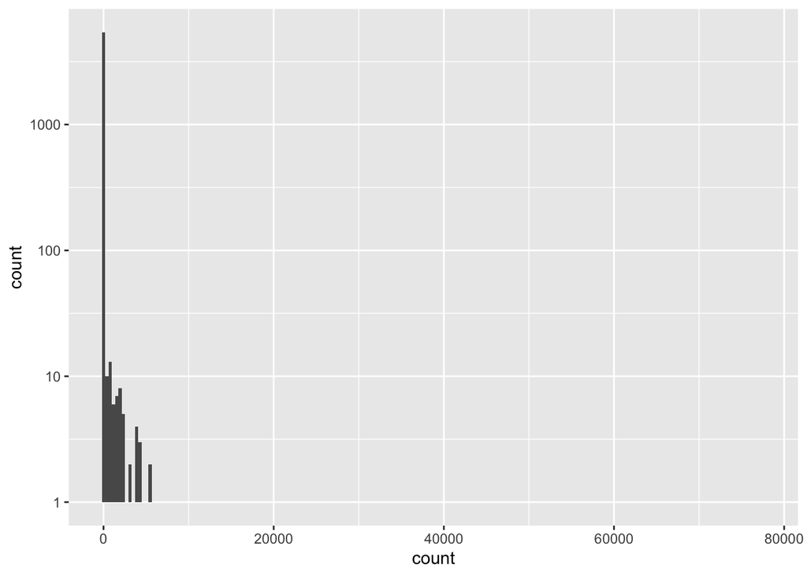

```r
ggplot(fc, aes(x = count)) +
  geom_histogram(bins = 200) +
  scale_y_log10()
```

# Salmon

## Load

```r
# read in raw data
sf <- read.table('quant.sf', header = 1)
Sys.setenv(PATH = paste("/Users/padilr1/opt/anaconda3/envs/r_env/bin", Sys.getenv("PATH"), sep=":"))
# import salmon results
sm <- tximport("quant.sf",
               type = "salmon",
               tx2gene = tx2gene,
               ignoreTxVersion = T)
```

## Per-transcript

```r
head(sf)
```

```
##                Name Length EffectiveLength      TPM NumReads
## 1 ENST00000456328.2   1657         1406.00 0.000000        0
## 2 ENST00000450305.2    632          381.00 0.000000        0
## 3 ENST00000488147.1   1351         1678.64 4.302518        1
## 4 ENST00000619216.1     68            2.00 0.000000        0
## 5 ENST00000473358.1    712          461.00 0.000000        0
## 6 ENST00000469289.1    535          284.00 0.000000        0
```

## Per-gene

```r
str(sm)
```

```
## List of 4
##  $ abundance          : num [1:5437, 1] 1.4 0 0 0 0 ...
##   ..- attr(*, "dimnames")=List of 2
##   .. ..$ : chr [1:5437] "ENSG00000000457" "ENSG00000000460" "ENSG00000000938" "ENSG00000000971" ...
##   .. ..$ : NULL
##  $ counts             : num [1:5437, 1] 1 0 0 0 0 ...
##   ..- attr(*, "dimnames")=List of 2
##   .. ..$ : chr [1:5437] "ENSG00000000457" "ENSG00000000460" "ENSG00000000938" "ENSG00000000971" ...
##   .. ..$ : NULL
##  $ length             : num [1:5437, 1] 5141 2180 1471 2309 1434 ...
##   ..- attr(*, "dimnames")=List of 2
##   .. ..$ : chr [1:5437] "ENSG00000000457" "ENSG00000000460" "ENSG00000000938" "ENSG00000000971" ...
##   .. ..$ : NULL
##  $ countsFromAbundance: chr "no"
```

# Comparison

## Merge

```r
# merge by ensembl gene id
both <- fc %>% mutate(Geneid = sub('\\..*', '', Geneid)) %>%
  merge(sm$counts, by.x = 'Geneid', by.y = 'row.names') %>%
  dplyr::rename(sm = V1, fc = count)
```

## Unexpressed

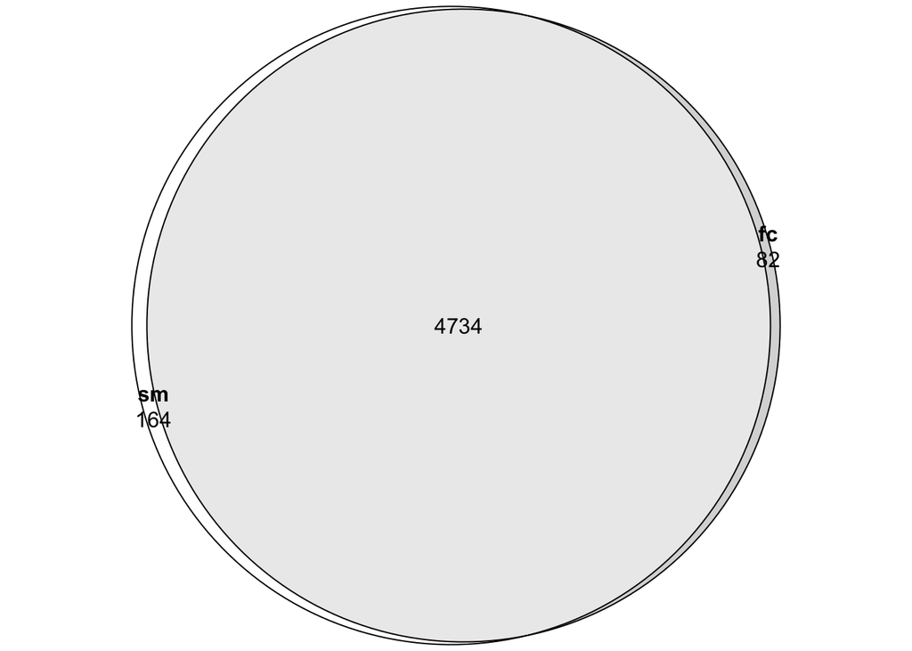

```r
fit <- lapply(both[c('sm', 'fc')], `==`, 0) %>%
  bind_cols() %>%
  euler()
plot(fit, quantities = T)
```

## Expressed

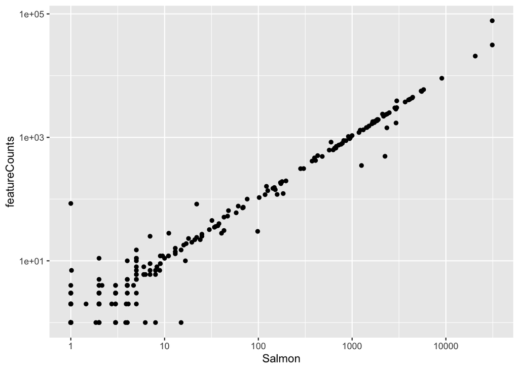

```r
both %>%
  dplyr::filter(fc != 0 & sm != 0) %>%
  ggplot(aes(x = sm, y = fc)) +
  geom_point() +
  scale_x_log10() +
  scale_y_log10() +
  labs(x = 'Salmon', y = 'featureCounts')
```

## Create DESeq object

```r
mat <- as.matrix(both[,c('fc','sm')])
cdat <- data.frame(kind = colnames(mat)) %>% `rownames<-`(colnames(mat))
dds <- DESeqDataSetFromMatrix(countData = round(mat),
                              colData = cdat,
                              design = ~kind)
dds
```

```
## class: DESeqDataSet
## dim: 5437 2
## metadata(1): version
## assays(1): counts
## rownames: NULL
## rowData names(0):
## colnames(2): fc sm
## colData names(1): kind
```

# Full dataset

## Load

```r
# load full dataset
load('lec5.rda')

# take a look at "data"
head(data)
```

```
##                 Irrel_kd_1 Irrel_kd_2 Irrel_kd_3 Mov10_kd_2 Mov10_kd_3
## ENSG00000000003       4376       3646       2968       6177       3688
## ENSG00000000005         27         29         23         37         13
## ENSG00000000419       1478       1288        884       2368       1340
## ENSG00000000457        508        405        357        934        571
## ENSG00000000460       1394       1165        850       2172       1217
## ENSG00000000938          1          1          0          2          0
##                 Mov10_oe_1 Mov10_oe_2 Mov10_oe_3
## ENSG00000000003       3343       3114       2079
## ENSG00000000005         25         38         22
## ENSG00000000419       1890       1766       1271
## ENSG00000000457        647        591        354
## ENSG00000000460       1184       1139        673
## ENSG00000000938          0          0          0
```

## Variance stabilization

Although differential expression analysis requires raw counts, transformed data generally works better for visualization, clustering, and other uses. Compare a simple log2 transformation versus the regularized log and variance stabilizing transformations.

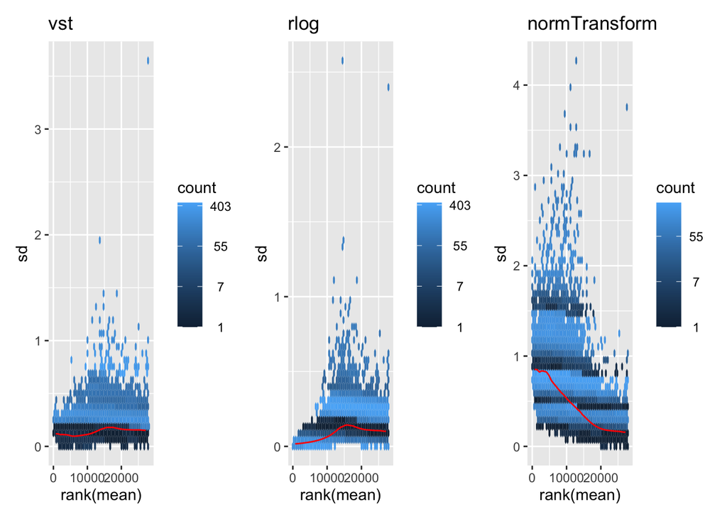

```r
keep <- rowSums(counts(dds)) >= 10
dds.filt <- dds[keep,]

# variance stabilizing, regularized log, and shift log transformations
lapply(c('vst', 'rlog', 'normTransform'), function(x) {
  match.fun(x)(dds.filt) %>%
    assay() %>%
    meanSdPlot(plot = F) %>%
    .$gg +
    ggtitle(x)
}) %>% wrap_plots(nrow = 1)
```

## Dimension reduction

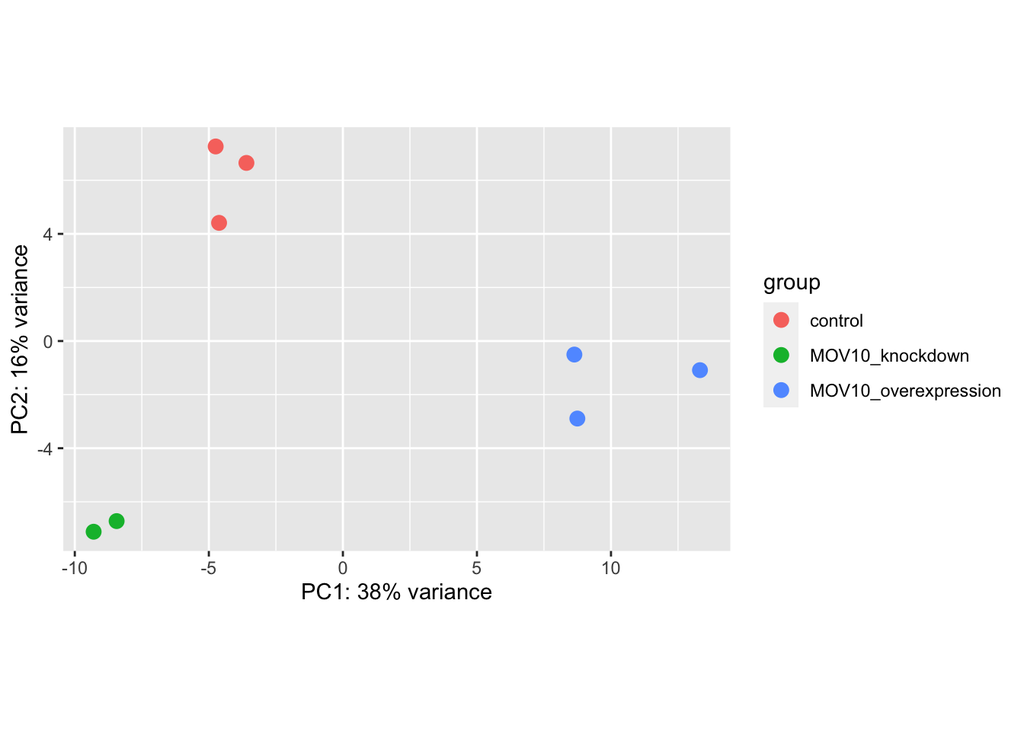

```r
vsd <- vst(dds.filt)
plotPCA(vsd)
```

## Hierarchical clustering

There are too many genes to perform hierarchical clustering quickly, so a subset of data will be looked at instead.

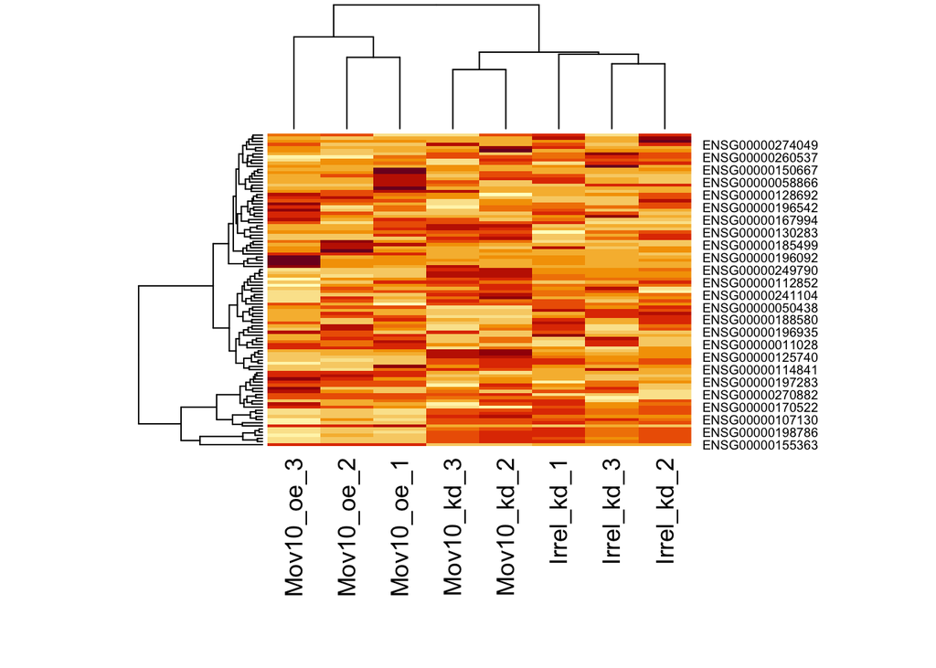

```r
# how can you subset the data?
select <- assay(vsd) %>%
  apply(1, sd) %>%
  order(decreasing = TRUE) %>%
  .[1:100]
heatmap(assay(vsd)[select,], margins = c(10, 5))
```

## Spot-check

Pick a gene, does the expression level seem different between conditions?

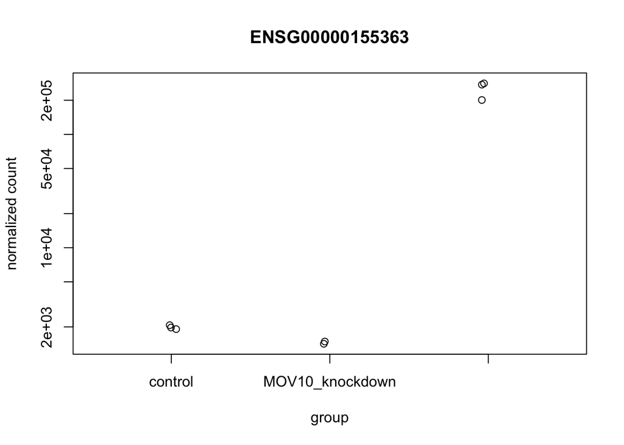

```r
plotCounts(dds.filt, gene = select[1], intgroup = "condition")
```

# Your turn

Load the featureCount dataset `ex2_featureCounts.txt`.

## Load

```r
fc <- read.table("~/Documents/HGEN_663/extra/lec5/ex2_featureCounts.txt",header=1)
```

## Create DESeq object

Remove unnecessary columns. An example of how to generate a metadata object is indicated below. Within the metadata dataframe, create another column called `condition`, grouping together the parental (PA), NSD1 knockout (NSD1KO) and NSD1/2 double knockouts (NSD12DKO) samples. Use `~condition` in the design parameter when creating your DESeq object.

```r
df <- fc %>%
  dplyr::select(-c(2:6)) %>%
  tibble::column_to_rownames("Geneid")
mat <- df %>% as.matrix()
metadata <- data.frame(kind=colnames(mat))
metadata$condition <- "PA"
metadata[3:4,"condition"] <- "NSD1KO"
metadata[5:6,"condition"] <- "NSD12DKO"
metadata <- tibble::column_to_rownames(metadata,"kind")
dds <- DESeqDataSetFromMatrix(countData = mat,
                              colData = metadata,
                              design = ~condition)
```

## Apply `vst` transformation

```r
vst <- varianceStabilizingTransformation(dds)
```

## PCA

Plot only the top 500 most variable genes.

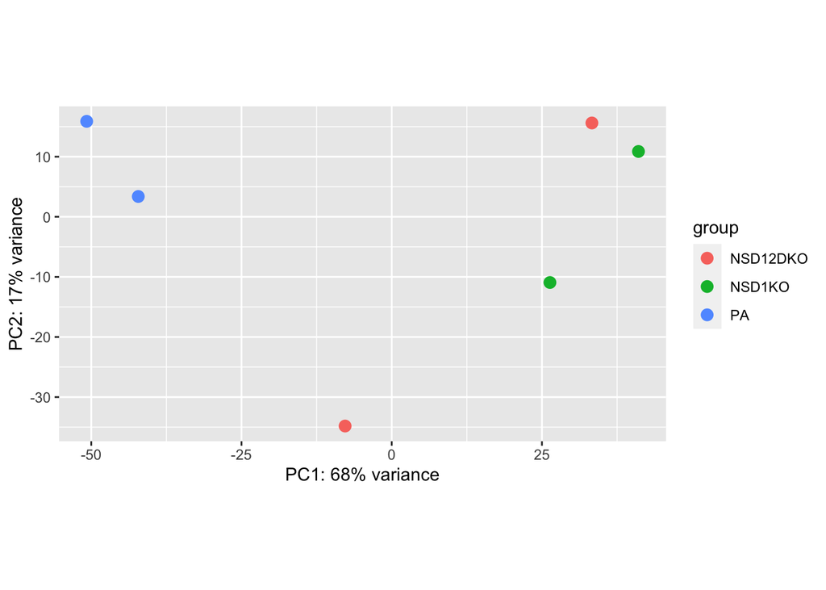

```r
# subset data
select <- assay(vst) %>%
  apply(1, sd) %>%
  order(decreasing = TRUE) %>%
  .[1:500]
vst_filt <- vst[select,]
#
plotPCA(vst_filt)
```

## Hierarchical clustering

Do the same as above for hierarchical clustering.

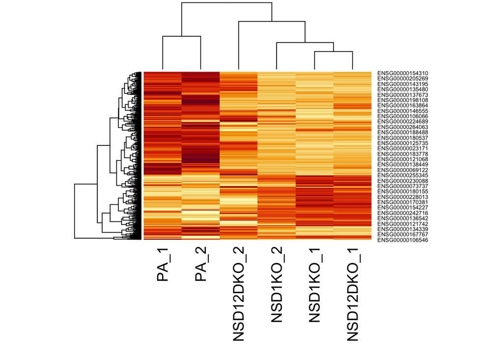

```r
heatmap(assay(vst_filt), margins = c(10, 5))
```

## Spotcheck

Google the ensembl id for NSD1 (in humans). Plot the expression level. Does the expression level seem different between the knockout and parental samples?

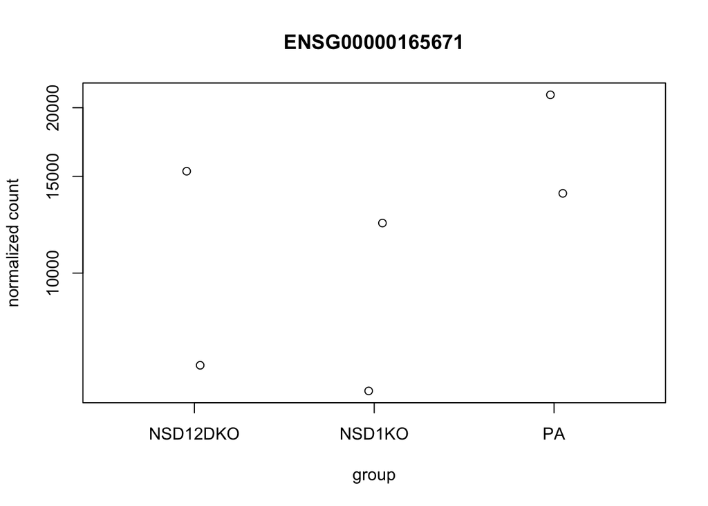

```r
# NSD1 = ENSG00000165671
# NSD2 = ENSG00000109685
plotCounts(dds,gene = "ENSG00000165671",intgroup = "condition")
```